# Blog_teste

Humberto Silva

17/04/2020

## Coronavirus: The case of Portugal

This post was made for didatical purposes and intends to help a better understand about how is possible to study this disease, in particular the portuguese case. This was inspired in the reading of https://blog.ephorie.de/epidemiology-how-contagious-is-novel-coronavirus-2019-ncov?fbclid=IwAR35_eyO1Ry6Bru04WKKPNv7mxt5rhNT_liU6QlEqJ8u-BrOZoVHxxJ0jbM, wich I am giving the credits for this work. First of all my academic background is Biotecnology and Chemistry, so I have some concepts, however not specialized in epidemioloy, thus wanted to improve my knowlege about this theme. I choosed to use the software R for the calculations and models for the data.

So the first question is how is possible for the epidmiologists to predict how contagiouse a virus is?

There are diverse models available so here I will use the simpliest and very well known SIR model (ver wikipedia). All the numbers I will use for this study come from the oficial authorities from the start point. The further analyses is mine.

Why is so important to have insights about this? The health and economy are two faces of any epidemie. In one hand We need to save lives and in the other we need to maintain our jobs, social services, and keep all the activities that we need to survive (agriculture, industry, services and others) so kill all the economy it’s not desirable too. How do we achieve this balance? In my opinion a main effort should be made in saving lives So the measures should be so restritive as necessary to avoid the colapse of the health system .

In wich phase of infection we are in Portugal so far? So we need to analyse the confirmed Cases acumulated in time. Let’s do it.

First we need to find a credible source available. Because the data in DGS are in PDF files we need a better solution to quikly acquiring data in a automatic way from the WEB. Unfortantly, the code works in this html source (https://pt.wikipedia.org/wiki/Pandemia_de_COVID-19_em_Portugal#Evolu%C3%A7%C3%A3o_dos_casos) but if the layout is changed, we need rearrange the code for another source and to have that in mind. Another solution is insert the values in a .CSV file, .txt file or manually but I will not dive in it.

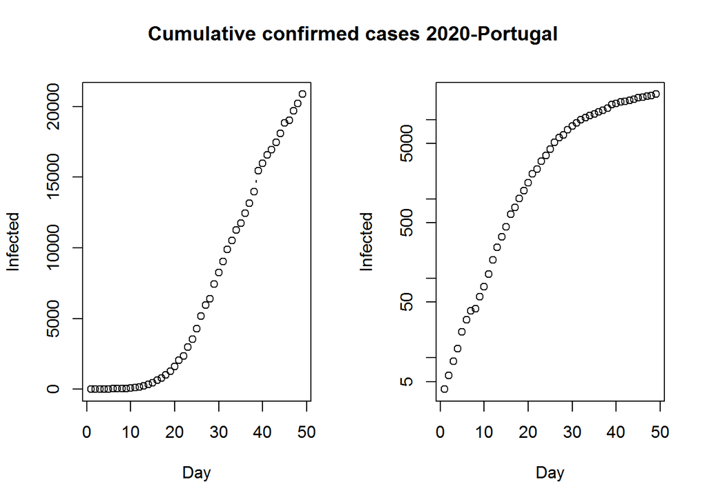

The graphic in the left is the number of infected people by time and in the right the same but with a log scale on the y-axis (a log-linear plot), and seems that the curve is flatening showing Portugal finished the exponecial growth phase, or the rate of growth is much more slower now. We will see more in detail this point. Now we come to the prediction part with the SIR model, which basic idea is quite simple. There are three groups of people: those that are healthy but susceptible to the disease (S), the infected (I) and the people who have recovered (R):

$$\frac{dS}{dt} = - \frac{\beta I S}{N}$$

$$\frac{dI}{dt} = \frac{\beta I S}{N}- \gamma I$$

$$\frac{dR}{dt} = \gamma I$$

To fit the model to the data we need two things: a solver for differential equations and an optimizer. To solve differential equations the function ode from the deSolve package (on CRAN) is an excellent choice, to optimize we will use the optim function from base R. Concretely, we will minimize the sum of the squared differences between the number of infected I at time t and the corresponding number of predicted cases by our model ^{I}(t):

$$RSS(\beta, \gamma) = \sum_{t} \left( I(t)-\^{I}(t) \right)^2$$

Putting it all together:

```
## [1] "CONVERGENCE: REL_REDUCTION_OF_F <= FACTR*EPSMCH"
```

```
##      beta     gamma
## 0.5938285 0.4061747
```

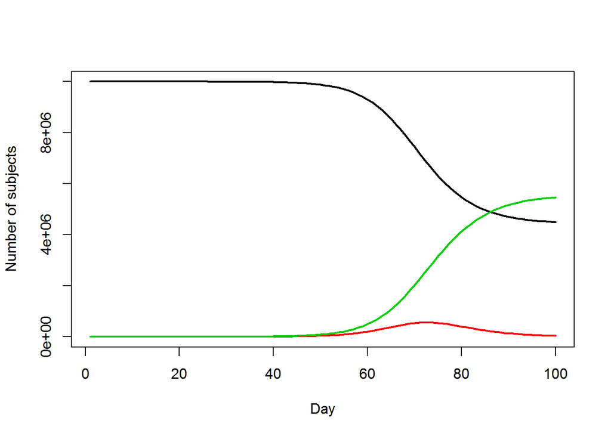

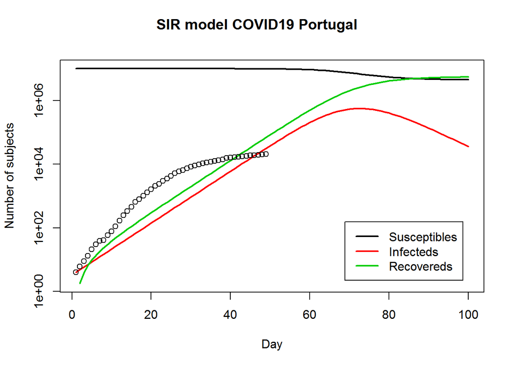

So observing our experimental points until 19-04-2020, we conclude this model it’s not fiting very well. This can happen because it’s too simplist to explain the behavior of the infection at this stage, it doesn’t include the containment measures efects. However from the literature we know that in the begining the growth rate is exponencial and so let’s check if the model can predict if nothing was been done. We going to rebuid only with the days until 20-03-2020, assuming that in this phase we were having transmission in the comunity in average 14 days before the people have syntomes actualy having positive tests.

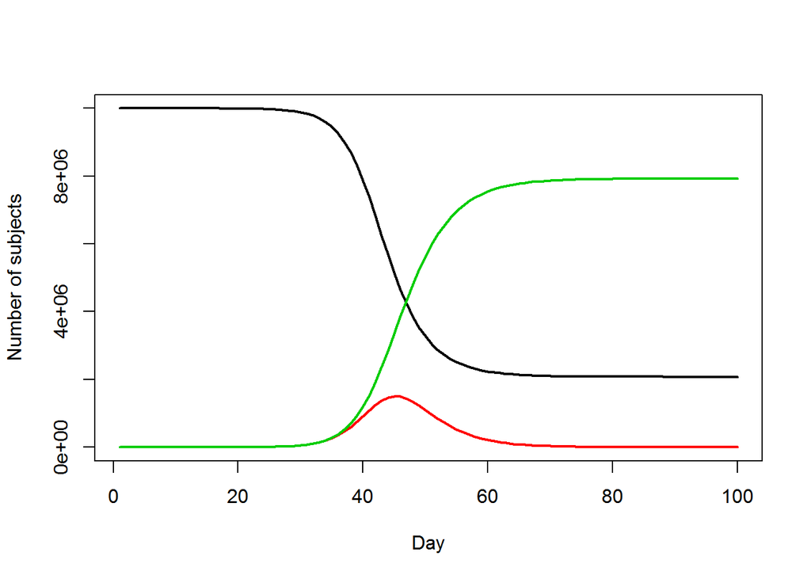

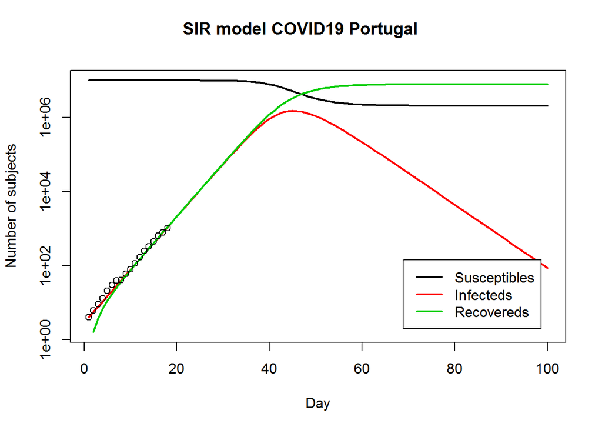

We have a good fitting now, not perfect indeed as noticed before for the same reasons: it’s too simplistic. Thus giving us a first aproximation to the reality, and permit estimate some coeficients. Let’s try to make it more realistic. We should keep in mind that a curve epidemic should be made with the “dates of begining of synthomes of the subjects” and here we are using the confirmed cases, so the quality of the data is very important.

```
##      R0
## 1.98384
```

```
##          I
## 45 1505232
```

```
## [1] 30104.65
```

So, R_0 is estimated in 1.9, which is consistent with the number that many researchers and the WHO give and which is around the same range of SARS, Influenza or Ebola (while transmission of Ebola is via bodily fluids and not airborne droplets).

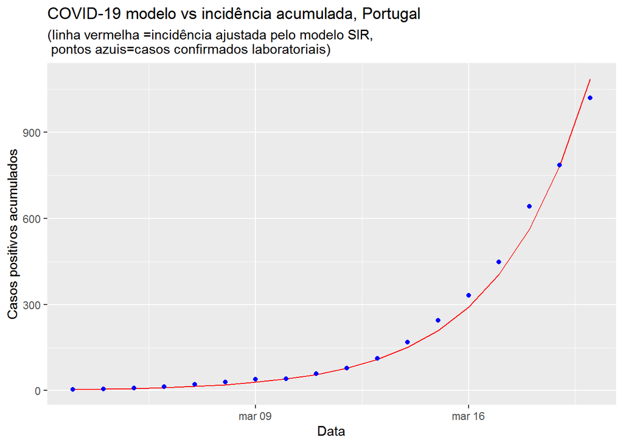

[figure not shown]